# cSAR geometry

##Read data and libraries

```r
library(readxl)
library(sf)
library(terra)
library(dplyr)
library(purrr)
data=read_excel("coa_pa99_centroides.xlsx")
```

##Generate and plot points and minimum convex polygon

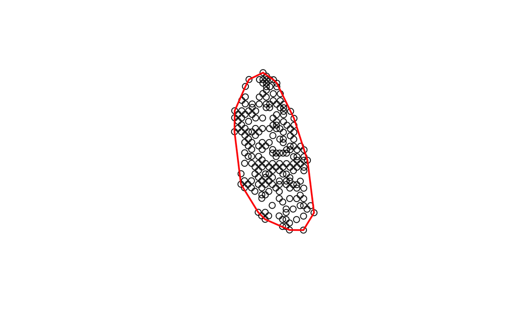

```r
points = st_as_sf(data,coords=c("long","lat"), crs=3763)
plot(st_geometry(points))

convex_hull <- st_convex_hull(st_union(points))
plot(convex_hull, border = "red", lwd = 2, add = TRUE)
```

```r
st_coordinates(convex_hull)[1,]
```

```
        X         Y        L1        L2
107216.34  66559.27      1.00      1.00
```

```r
points[1,]
```

```
Simple feature collection with 1 feature and 139 fields
Geometry type: POINT
Dimension:     XY
Bounding box:  xmin: 71411.41 ymin: 92851.93 xmax: 71411.41 ymax: 92851.93
Projected CRS: ETRS89 / Portugal TM06
```

| location | accipiter gentilis | accipiter nisus | actitis hypoleucos | aegithalos caudatus | aegypius monachus | alauda arvensis | alcedo atthis | alectoris rufa | anas platyrhynchos | anthus campestris | anthus pratensis | apus apus | aquila chrysaetos | ardea cinerea | athene noctua | bubo bubo | burhinus oedicnemus | buteo buteo | calandrella brachydactyla | carduelis carduelis | carduelis spinus | cecropis daurica | certhia brachydactyla | cettia cetti | charadrius dubius | chloris chloris | ciconia ciconia | cinclus cinclus | circaetus gallicus | … |
| --- | --- | --- | --- | --- | --- | --- | --- | --- | --- | --- | --- | --- | --- | --- | --- | --- | --- | --- | --- | --- | --- | --- | --- | --- | --- | --- | --- | --- | --- | --- |
| pe48m | 0 | 0 | 0 | 0 | 0 | 1 | 0 | 0 | 0 | 0 | 0 | 1 | 0 | 0 | 0 | 0 | 0 | 0 | 0 | 0 | 0 | 0 | 0 | 0 | 0 | 0 | 0 | 0 | 0 | … |

##filter_points_in_expanding_circles A function that picks a random point and starts sampling increasing circles from those points, returning the points inside those circles.

```r
filter_points_in_expanding_circles <- function(points_sf, radius_vector, convex_hull) {
  # Randomly select one point from points_sf
  selected_point <- points_sf[sample(1:nrow(points_sf), 1), ]

  # Initialize a list to store points within each circle
  points_within_circles <- list()

  # Loop through the radius_vector
  for (radius in radius_vector) {
    # Create a buffer (circle) around the selected point with the current radius
    circle <- st_geometry(st_buffer(selected_point, dist = radius))

    # Calculate the intersection of the circle with the convex_hull
    intersection <- st_intersection(circle, convex_hull)

    # Check the area of the intersection compared to the area of the circle
    circle_area <- as.numeric(st_area(circle)) #as.numeric to remove units

    intersection_area <- as.numeric(st_area(intersection)) #as.numeric to remove units

    # Stop if the majority of the circle is outside the convex_hull
    if (intersection_area / circle_area < 0.5) {
      break
    }

    # Find points_sf that intersect the current circle
    points_in_circle <- points_sf[st_intersects(points_sf, circle, sparse = FALSE), ]

    # Add the points to the list
    points_within_circles[[paste0("radius_", radius)]] <-
      list(points=points_in_circle,circle=circle)
  }

  # Return the list of points within circles
  return(points_within_circles)
}
```

test the function

```r
pt_in_circles = filter_points_in_expanding_circles(points,2000*1:10,convex_hull)

plot(st_geometry(points))
plot(convex_hull, border = "red", lwd = 2, add=TRUE)
```

```
Simple feature collection with 1 feature and 139 fields
Geometry type: POINT
Dimension:     XY
Bounding box:  xmin: 89317.34 ymin: 80712.32 xmax: 89317.34 ymax: 80712.32
Projected CRS: ETRS89 / Portugal TM06
```

| location | accipiter gentilis | accipiter nisus | actitis hypoleucos | aegithalos caudatus | aegypius monachus | alauda arvensis | alcedo atthis | alectoris rufa | anas platyrhynchos | anthus campestris | anthus pratensis | apus apus | aquila chrysaetos | ardea cinerea | athene noctua | bubo bubo | burhinus oedicnemus | buteo buteo | calandrella brachydactyla | carduelis carduelis | carduelis spinus | cecropis daurica | certhia brachydactyla | cettia cetti | charadrius dubius | chloris chloris | ciconia ciconia | cinclus cinclus | circaetus gallicus | … |
| --- | --- | --- | --- | --- | --- | --- | --- | --- | --- | --- | --- | --- | --- | --- | --- | --- | --- | --- | --- | --- | --- | --- | --- | --- | --- | --- | --- | --- | --- | --- |
| pe67g | 0 | 0 | 0 | 0 | 0 | 0 | 0 | 0 | 0 | 0 | 0 | 0 | 0 | 0 | 0 | 0 | 0 | 0 | 0 | 1 | 0 | 0 | 0 | 0 | 0 | 0 | 0 | 0 | 0 | … |

```
Simple feature collection with 1 feature and 139 fields
Geometry type: POINT
Dimension:     XY
Bounding box:  xmin: 89317.34 ymin: 80712.32 xmax: 89317.34 ymax: 80712.32
Projected CRS: ETRS89 / Portugal TM06
```

| location | accipiter gentilis | accipiter nisus | actitis hypoleucos | aegithalos caudatus | aegypius monachus | alauda arvensis | alcedo atthis | alectoris rufa | anas platyrhynchos | anthus campestris | anthus pratensis | apus apus | aquila chrysaetos | ardea cinerea | athene noctua | bubo bubo | burhinus oedicnemus | buteo buteo | calandrella brachydactyla | carduelis carduelis | carduelis spinus | cecropis daurica | certhia brachydactyla | cettia cetti | charadrius dubius | chloris chloris | ciconia ciconia | cinclus cinclus | circaetus gallicus | … |
| --- | --- | --- | --- | --- | --- | --- | --- | --- | --- | --- | --- | --- | --- | --- | --- | --- | --- | --- | --- | --- | --- | --- | --- | --- | --- | --- | --- | --- | --- | --- |
| pe67g | 0 | 0 | 0 | 0 | 0 | 0 | 0 | 0 | 0 | 0 | 0 | 0 | 0 | 0 | 0 | 0 | 0 | 0 | 0 | 1 | 0 | 0 | 0 | 0 | 0 | 0 | 0 | 0 | 0 | … |

```
Simple feature collection with 3 features and 139 fields
Geometry type: POINT
Dimension:     XY
Bounding box:  xmin: 85286.38 ymin: 76743.63 xmax: 93348.3 ymax: 84681.07
Projected CRS: ETRS89 / Portugal TM06
```

| location | accipiter gentilis | accipiter nisus | actitis hypoleucos | aegithalos caudatus | aegypius monachus | alauda arvensis | alcedo atthis | alectoris rufa | anas platyrhynchos | anthus campestris | anthus pratensis | apus apus | aquila chrysaetos | ardea cinerea | athene noctua | bubo bubo | burhinus oedicnemus | buteo buteo | calandrella brachydactyla | carduelis carduelis | carduelis spinus | cecropis daurica | certhia brachydactyla | cettia cetti | charadrius dubius | chloris chloris | ciconia ciconia | cinclus cinclus | circaetus gallicus | … |
| --- | --- | --- | --- | --- | --- | --- | --- | --- | --- | --- | --- | --- | --- | --- | --- | --- | --- | --- | --- | --- | --- | --- | --- | --- | --- | --- | --- | --- | --- | --- |
| pe56z | 0 | 0 | 0 | 0 | 0 | 0 | 0 | 0 | 0 | 0 | 0 | 1 | 0 | 0 | 0 | 0 | 0 | 1 | 0 | 0 | 0 | 0 | 0 | 0 | 0 | 0 | 0 | 0 | 1 | … |
| pe67g | 0 | 0 | 0 | 0 | 0 | 0 | 0 | 0 | 0 | 0 | 0 | 0 | 0 | 0 | 0 | 0 | 0 | 0 | 0 | 1 | 0 | 0 | 0 | 0 | 0 | 0 | 0 | 0 | 0 | … |
| pe67t | 0 | 0 | 0 | 0 | 0 | 0 | 0 | 0 | 0 | 0 | 0 | 1 | 0 | 0 | 0 | 0 | 0 | 0 | 0 | 1 | 0 | 0 | 0 | 0 | 0 | 0 | 0 | 0 | 0 | … |

```
Simple feature collection with 8 features and 139 fields
Geometry type: POINT
Dimension:     XY
Bounding box:  xmin: 83348.72 ymin: 74681.45 xmax: 95332.68 ymax: 86743.25
Projected CRS: ETRS89 / Portugal TM06
```

| location | accipiter gentilis | accipiter nisus | actitis hypoleucos | aegithalos caudatus | aegypius monachus | alauda arvensis | alcedo atthis | alectoris rufa | anas platyrhynchos | anthus campestris | anthus pratensis | apus apus | aquila chrysaetos | ardea cinerea | athene noctua | bubo bubo | burhinus oedicnemus | buteo buteo | calandrella brachydactyla | carduelis carduelis | carduelis spinus | cecropis daurica | certhia brachydactyla | cettia cetti | charadrius dubius | chloris chloris | ciconia ciconia | cinclus cinclus | circaetus gallicus | … |
| --- | --- | --- | --- | --- | --- | --- | --- | --- | --- | --- | --- | --- | --- | --- | --- | --- | --- | --- | --- | --- | --- | --- | --- | --- | --- | --- | --- | --- | --- | --- |
| pe56z | 0 | 0 | 0 | 0 | 0 | 0 | 0 | 0 | 0 | 0 | 0 | 1 | 0 | 0 | 0 | 0 | 0 | 1 | 0 | 0 | 0 | 0 | 0 | 0 | 0 | 0 | 0 | 0 | 1 | … |
| pe57t | 0 | 0 | 0 | 0 | 0 | 0 | 0 | 0 | 0 | 0 | 0 | 0 | 0 | 0 | 0 | 0 | 0 | 0 | 0 | 0 | 0 | 0 | 1 | 0 | 0 | 0 | 0 | 0 | 0 | … |
| pe57z | 0 | 0 | 0 | 0 | 0 | 0 | 0 | 0 | 0 | 0 | 0 | 0 | 0 | 0 | 0 | 0 | 0 | 1 | 0 | 0 | 0 | 0 | 0 | 1 | 0 | 0 | 0 | 0 | 0 | … |
| pe66d | 0 | 0 | 0 | 0 | 0 | 0 | 0 | 0 | 0 | 0 | 0 | 0 | 0 | 0 | 0 | 0 | 0 | 0 | 0 | 0 | 0 | 0 | 1 | 1 | 0 | 0 | 0 | 0 | 0 | … |
| pe66t | 0 | 0 | 0 | 1 | 0 | 0 | 0 | 0 | 0 | 0 | 0 | 0 | 0 | 0 | 0 | 0 | 0 | 1 | 0 | 0 | 0 | 0 | 0 | 0 | 0 | 0 | 0 | 0 | 0 | … |
| pe67g | 0 | 0 | 0 | 0 | 0 | 0 | 0 | 0 | 0 | 0 | 0 | 0 | 0 | 0 | 0 | 0 | 0 | 0 | 0 | 1 | 0 | 0 | 0 | 0 | 0 | 0 | 0 | 0 | 0 | … |
| pe67t | 0 | 0 | 0 | 0 | 0 | 0 | 0 | 0 | 0 | 0 | 0 | 1 | 0 | 0 | 0 | 0 | 0 | 0 | 0 | 1 | 0 | 0 | 0 | 0 | 0 | 0 | 0 | 0 | 0 | … |
| pe67x | 0 | 0 | 0 | 0 | 0 | 0 | 0 | 1 | 0 | 0 | 0 | 0 | 0 | 0 | 0 | 0 | 0 | 1 | 0 | 0 | 0 | 0 | 0 | 0 | 0 | 0 | 0 | 0 | 0 | … |

```
Simple feature collection with 16 features and 139 fields
Geometry type: POINT
Dimension:     XY
Bounding box:  xmin: 81286.53 ymin: 72743.77 xmax: 97301.47 ymax: 88727.58
Projected CRS: ETRS89 / Portugal TM06
```

| location | accipiter gentilis | accipiter nisus | actitis hypoleucos | aegithalos caudatus | aegypius monachus | alauda arvensis | alcedo atthis | alectoris rufa | anas platyrhynchos | anthus campestris | anthus pratensis | apus apus | aquila chrysaetos | ardea cinerea | athene noctua | bubo bubo | burhinus oedicnemus | buteo buteo | calandrella brachydactyla | carduelis carduelis | carduelis spinus | cecropis daurica | certhia brachydactyla | cettia cetti | charadrius dubius | chloris chloris | ciconia ciconia | cinclus cinclus | circaetus gallicus | … |
| --- | --- | --- | --- | --- | --- | --- | --- | --- | --- | --- | --- | --- | --- | --- | --- | --- | --- | --- | --- | --- | --- | --- | --- | --- | --- | --- | --- | --- | --- | --- |
| pe56p | 0 | 0 | 0 | 0 | 0 | 0 | 0 | 0 | 0 | 0 | 0 | 0 | 0 | 0 | 0 | 0 | 0 | 1 | 0 | 0 | 0 | 0 | 1 | 0 | 0 | 0 | 0 | 0 | 0 | … |
| pe56t | 0 | 0 | 0 | 0 | 0 | 0 | 0 | 0 | 0 | 0 | 1 | 0 | 0 | 0 | 0 | 0 | 0 | 1 | 0 | 0 | 0 | 0 | 1 | 1 | 0 | 1 | 0 | 0 | 0 | … |
| pe56x | 0 | 0 | 0 | 0 | 0 | 0 | 0 | 0 | 0 | 0 | 1 | 0 | 0 | 0 | 0 | 0 | 0 | 0 | 0 | 0 | 0 | 0 | 1 | 0 | 0 | 0 | 0 | 0 | 0 | … |
| pe56z | 0 | 0 | 0 | 0 | 0 | 0 | 0 | 0 | 0 | 0 | 0 | 1 | 0 | 0 | 0 | 0 | 0 | 1 | 0 | 0 | 0 | 0 | 0 | 0 | 0 | 0 | 0 | 0 | 1 | … |
| pe57t | 0 | 0 | 0 | 0 | 0 | 0 | 0 | 0 | 0 | 0 | 0 | 0 | 0 | 0 | 0 | 0 | 0 | 0 | 0 | 0 | 0 | 0 | 1 | 0 | 0 | 0 | 0 | 0 | 0 | … |
| pe57u | 0 | 0 | 0 | 0 | 0 | 0 | 0 | 0 | 0 | 1 | 0 | 0 | 0 | 0 | 0 | 0 | 0 | 0 | 0 | 0 | 0 | 0 | 1 | 0 | 0 | 0 | 0 | 0 | 0 | … |
| pe57z | 0 | 0 | 0 | 0 | 0 | 0 | 0 | 0 | 0 | 0 | 0 | 0 | 0 | 0 | 0 | 0 | 0 | 1 | 0 | 0 | 0 | 0 | 0 | 1 | 0 | 0 | 0 | 0 | 0 | … |
| pe66d | 0 | 0 | 0 | 0 | 0 | 0 | 0 | 0 | 0 | 0 | 0 | 0 | 0 | 0 | 0 | 0 | 0 | 0 | 0 | 0 | 0 | 0 | 1 | 1 | 0 | 0 | 0 | 0 | 0 | … |
| pe66t | 0 | 0 | 0 | 1 | 0 | 0 | 0 | 0 | 0 | 0 | 0 | 0 | 0 | 0 | 0 | 0 | 0 | 1 | 0 | 0 | 0 | 0 | 0 | 0 | 0 | 0 | 0 | 0 | 0 | … |
| pe67g | 0 | 0 | 0 | 0 | 0 | 0 | 0 | 0 | 0 | 0 | 0 | 0 | 0 | 0 | 0 | 0 | 0 | 0 | 0 | 1 | 0 | 0 | 0 | 0 | 0 | 0 | 0 | 0 | 0 | … |

[output cut: 6 more lines]

```
Simple feature collection with 21 features and 139 fields
Geometry type: POINT
Dimension:     XY
Bounding box:  xmin: 81286.53 ymin: 72650.43 xmax: 99348.06 ymax: 90758.66
Projected CRS: ETRS89 / Portugal TM06
```

| location | accipiter gentilis | accipiter nisus | actitis hypoleucos | aegithalos caudatus | aegypius monachus | alauda arvensis | alcedo atthis | alectoris rufa | anas platyrhynchos | anthus campestris | anthus pratensis | apus apus | aquila chrysaetos | ardea cinerea | athene noctua | bubo bubo | burhinus oedicnemus | buteo buteo | calandrella brachydactyla | carduelis carduelis | carduelis spinus | cecropis daurica | certhia brachydactyla | cettia cetti | charadrius dubius | chloris chloris | ciconia ciconia | cinclus cinclus | circaetus gallicus | … |
| --- | --- | --- | --- | --- | --- | --- | --- | --- | --- | --- | --- | --- | --- | --- | --- | --- | --- | --- | --- | --- | --- | --- | --- | --- | --- | --- | --- | --- | --- | --- |
| pe56p | 0 | 0 | 0 | 0 | 0 | 0 | 0 | 0 | 0 | 0 | 0 | 0 | 0 | 0 | 0 | 0 | 0 | 1 | 0 | 0 | 0 | 0 | 1 | 0 | 0 | 0 | 0 | 0 | 0 | … |
| pe56t | 0 | 0 | 0 | 0 | 0 | 0 | 0 | 0 | 0 | 0 | 1 | 0 | 0 | 0 | 0 | 0 | 0 | 1 | 0 | 0 | 0 | 0 | 1 | 1 | 0 | 1 | 0 | 0 | 0 | … |
| pe56x | 0 | 0 | 0 | 0 | 0 | 0 | 0 | 0 | 0 | 0 | 1 | 0 | 0 | 0 | 0 | 0 | 0 | 0 | 0 | 0 | 0 | 0 | 1 | 0 | 0 | 0 | 0 | 0 | 0 | … |
| pe56z | 0 | 0 | 0 | 0 | 0 | 0 | 0 | 0 | 0 | 0 | 0 | 1 | 0 | 0 | 0 | 0 | 0 | 1 | 0 | 0 | 0 | 0 | 0 | 0 | 0 | 0 | 0 | 0 | 1 | … |
| pe57t | 0 | 0 | 0 | 0 | 0 | 0 | 0 | 0 | 0 | 0 | 0 | 0 | 0 | 0 | 0 | 0 | 0 | 0 | 0 | 0 | 0 | 0 | 1 | 0 | 0 | 0 | 0 | 0 | 0 | … |
| pe57u | 0 | 0 | 0 | 0 | 0 | 0 | 0 | 0 | 0 | 1 | 0 | 0 | 0 | 0 | 0 | 0 | 0 | 0 | 0 | 0 | 0 | 0 | 1 | 0 | 0 | 0 | 0 | 0 | 0 | … |
| pe57z | 0 | 0 | 0 | 0 | 0 | 0 | 0 | 0 | 0 | 0 | 0 | 0 | 0 | 0 | 0 | 0 | 0 | 1 | 0 | 0 | 0 | 0 | 0 | 1 | 0 | 0 | 0 | 0 | 0 | … |
| pe58r | 0 | 0 | 0 | 0 | 0 | 0 | 0 | 1 | 0 | 0 | 0 | 0 | 0 | 0 | 0 | 0 | 0 | 0 | 0 | 0 | 0 | 0 | 1 | 0 | 0 | 0 | 0 | 0 | 0 | … |
| pe66d | 0 | 0 | 0 | 0 | 0 | 0 | 0 | 0 | 0 | 0 | 0 | 0 | 0 | 0 | 0 | 0 | 0 | 0 | 0 | 0 | 0 | 0 | 1 | 1 | 0 | 0 | 0 | 0 | 0 | … |
| pe66t | 0 | 0 | 0 | 1 | 0 | 0 | 0 | 0 | 0 | 0 | 0 | 0 | 0 | 0 | 0 | 0 | 0 | 1 | 0 | 0 | 0 | 0 | 0 | 0 | 0 | 0 | 0 | 0 | 0 | … |

[output cut: 11 more lines]

```
Simple feature collection with 27 features and 139 fields
Geometry type: POINT
Dimension:     XY
Bounding box:  xmin: 79379.97 ymin: 68666.15 xmax: 101301.3 ymax: 92743.02
Projected CRS: ETRS89 / Portugal TM06
```

| location | accipiter gentilis | accipiter nisus | actitis hypoleucos | aegithalos caudatus | aegypius monachus | alauda arvensis | alcedo atthis | alectoris rufa | anas platyrhynchos | anthus campestris | anthus pratensis | apus apus | aquila chrysaetos | ardea cinerea | athene noctua | bubo bubo | burhinus oedicnemus | buteo buteo | calandrella brachydactyla | carduelis carduelis | carduelis spinus | cecropis daurica | certhia brachydactyla | cettia cetti | charadrius dubius | chloris chloris | ciconia ciconia | cinclus cinclus | circaetus gallicus | … |
| --- | --- | --- | --- | --- | --- | --- | --- | --- | --- | --- | --- | --- | --- | --- | --- | --- | --- | --- | --- | --- | --- | --- | --- | --- | --- | --- | --- | --- | --- | --- |
| pe56p | 0 | 0 | 0 | 0 | 0 | 0 | 0 | 0 | 0 | 0 | 0 | 0 | 0 | 0 | 0 | 0 | 0 | 1 | 0 | 0 | 0 | 0 | 1 | 0 | 0 | 0 | 0 | 0 | 0 | … |
| pe56t | 0 | 0 | 0 | 0 | 0 | 0 | 0 | 0 | 0 | 0 | 1 | 0 | 0 | 0 | 0 | 0 | 0 | 1 | 0 | 0 | 0 | 0 | 1 | 1 | 0 | 1 | 0 | 0 | 0 | … |
| pe56x | 0 | 0 | 0 | 0 | 0 | 0 | 0 | 0 | 0 | 0 | 1 | 0 | 0 | 0 | 0 | 0 | 0 | 0 | 0 | 0 | 0 | 0 | 1 | 0 | 0 | 0 | 0 | 0 | 0 | … |
| pe56z | 0 | 0 | 0 | 0 | 0 | 0 | 0 | 0 | 0 | 0 | 0 | 1 | 0 | 0 | 0 | 0 | 0 | 1 | 0 | 0 | 0 | 0 | 0 | 0 | 0 | 0 | 0 | 0 | 1 | … |
| pe57t | 0 | 0 | 0 | 0 | 0 | 0 | 0 | 0 | 0 | 0 | 0 | 0 | 0 | 0 | 0 | 0 | 0 | 0 | 0 | 0 | 0 | 0 | 1 | 0 | 0 | 0 | 0 | 0 | 0 | … |
| pe57u | 0 | 0 | 0 | 0 | 0 | 0 | 0 | 0 | 0 | 1 | 0 | 0 | 0 | 0 | 0 | 0 | 0 | 0 | 0 | 0 | 0 | 0 | 1 | 0 | 0 | 0 | 0 | 0 | 0 | … |
| pe57z | 0 | 0 | 0 | 0 | 0 | 0 | 0 | 0 | 0 | 0 | 0 | 0 | 0 | 0 | 0 | 0 | 0 | 1 | 0 | 0 | 0 | 0 | 0 | 1 | 0 | 0 | 0 | 0 | 0 | … |
| pe58f | 0 | 0 | 0 | 1 | 0 | 0 | 0 | 0 | 0 | 0 | 0 | 0 | 0 | 0 | 0 | 0 | 0 | 0 | 0 | 1 | 0 | 0 | 0 | 0 | 0 | 1 | 0 | 0 | 0 | … |
| pe58r | 0 | 0 | 0 | 0 | 0 | 0 | 0 | 1 | 0 | 0 | 0 | 0 | 0 | 0 | 0 | 0 | 0 | 0 | 0 | 0 | 0 | 0 | 1 | 0 | 0 | 0 | 0 | 0 | 0 | … |
| pe58x | 0 | 0 | 0 | 0 | 0 | 0 | 0 | 0 | 0 | 0 | 1 | 0 | 0 | 0 | 0 | 0 | 0 | 1 | 0 | 1 | 0 | 0 | 0 | 1 | 0 | 0 | 0 | 0 | 0 | … |

[output cut: 17 more lines]

```
Simple feature collection with 37 features and 139 fields
Geometry type: POINT
Dimension:     XY
Bounding box:  xmin: 77395.62 ymin: 68650.55 xmax: 103347.9 ymax: 94758.5
Projected CRS: ETRS89 / Portugal TM06
```

| location | accipiter gentilis | accipiter nisus | actitis hypoleucos | aegithalos caudatus | aegypius monachus | alauda arvensis | alcedo atthis | alectoris rufa | anas platyrhynchos | anthus campestris | anthus pratensis | apus apus | aquila chrysaetos | ardea cinerea | athene noctua | bubo bubo | burhinus oedicnemus | buteo buteo | calandrella brachydactyla | carduelis carduelis | carduelis spinus | cecropis daurica | certhia brachydactyla | cettia cetti | charadrius dubius | chloris chloris | ciconia ciconia | cinclus cinclus | circaetus gallicus | … |
| --- | --- | --- | --- | --- | --- | --- | --- | --- | --- | --- | --- | --- | --- | --- | --- | --- | --- | --- | --- | --- | --- | --- | --- | --- | --- | --- | --- | --- | --- | --- |
| pe56p | 0 | 0 | 0 | 0 | 0 | 0 | 0 | 0 | 0 | 0 | 0 | 0 | 0 | 0 | 0 | 0 | 0 | 1 | 0 | 0 | 0 | 0 | 1 | 0 | 0 | 0 | 0 | 0 | 0 | … |
| pe56t | 0 | 0 | 0 | 0 | 0 | 0 | 0 | 0 | 0 | 0 | 1 | 0 | 0 | 0 | 0 | 0 | 0 | 1 | 0 | 0 | 0 | 0 | 1 | 1 | 0 | 1 | 0 | 0 | 0 | … |
| pe56x | 0 | 0 | 0 | 0 | 0 | 0 | 0 | 0 | 0 | 0 | 1 | 0 | 0 | 0 | 0 | 0 | 0 | 0 | 0 | 0 | 0 | 0 | 1 | 0 | 0 | 0 | 0 | 0 | 0 | … |
| pe56z | 0 | 0 | 0 | 0 | 0 | 0 | 0 | 0 | 0 | 0 | 0 | 1 | 0 | 0 | 0 | 0 | 0 | 1 | 0 | 0 | 0 | 0 | 0 | 0 | 0 | 0 | 0 | 0 | 1 | … |
| pe57t | 0 | 0 | 0 | 0 | 0 | 0 | 0 | 0 | 0 | 0 | 0 | 0 | 0 | 0 | 0 | 0 | 0 | 0 | 0 | 0 | 0 | 0 | 1 | 0 | 0 | 0 | 0 | 0 | 0 | … |
| pe57u | 0 | 0 | 0 | 0 | 0 | 0 | 0 | 0 | 0 | 1 | 0 | 0 | 0 | 0 | 0 | 0 | 0 | 0 | 0 | 0 | 0 | 0 | 1 | 0 | 0 | 0 | 0 | 0 | 0 | … |
| pe57z | 0 | 0 | 0 | 0 | 0 | 0 | 0 | 0 | 0 | 0 | 0 | 0 | 0 | 0 | 0 | 0 | 0 | 1 | 0 | 0 | 0 | 0 | 0 | 1 | 0 | 0 | 0 | 0 | 0 | … |
| pe58b | 0 | 0 | 0 | 0 | 0 | 0 | 0 | 0 | 0 | 0 | 0 | 1 | 0 | 0 | 0 | 0 | 0 | 0 | 0 | 0 | 0 | 0 | 1 | 1 | 0 | 1 | 0 | 0 | 0 | … |
| pe58f | 0 | 0 | 0 | 1 | 0 | 0 | 0 | 0 | 0 | 0 | 0 | 0 | 0 | 0 | 0 | 0 | 0 | 0 | 0 | 1 | 0 | 0 | 0 | 0 | 0 | 1 | 0 | 0 | 0 | … |
| pe58m | 0 | 0 | 0 | 1 | 0 | 0 | 0 | 0 | 0 | 0 | 0 | 0 | 0 | 0 | 0 | 0 | 0 | 0 | 0 | 1 | 0 | 0 | 1 | 0 | 0 | 0 | 0 | 0 | 0 | … |

[output cut: 27 more lines]

```
Simple feature collection with 48 features and 139 fields
Geometry type: POINT
Dimension:     XY
Bounding box:  xmin: 77395.62 ymin: 66635.11 xmax: 105363.4 ymax: 96773.96
Projected CRS: ETRS89 / Portugal TM06
```

| location | accipiter gentilis | accipiter nisus | actitis hypoleucos | aegithalos caudatus | aegypius monachus | alauda arvensis | alcedo atthis | alectoris rufa | anas platyrhynchos | anthus campestris | anthus pratensis | apus apus | aquila chrysaetos | ardea cinerea | athene noctua | bubo bubo | burhinus oedicnemus | buteo buteo | calandrella brachydactyla | carduelis carduelis | carduelis spinus | cecropis daurica | certhia brachydactyla | cettia cetti | charadrius dubius | chloris chloris | ciconia ciconia | cinclus cinclus | circaetus gallicus | … |
| --- | --- | --- | --- | --- | --- | --- | --- | --- | --- | --- | --- | --- | --- | --- | --- | --- | --- | --- | --- | --- | --- | --- | --- | --- | --- | --- | --- | --- | --- | --- |
| pe56p | 0 | 0 | 0 | 0 | 0 | 0 | 0 | 0 | 0 | 0 | 0 | 0 | 0 | 0 | 0 | 0 | 0 | 1 | 0 | 0 | 0 | 0 | 1 | 0 | 0 | 0 | 0 | 0 | 0 | … |
| pe56t | 0 | 0 | 0 | 0 | 0 | 0 | 0 | 0 | 0 | 0 | 1 | 0 | 0 | 0 | 0 | 0 | 0 | 1 | 0 | 0 | 0 | 0 | 1 | 1 | 0 | 1 | 0 | 0 | 0 | … |
| pe56x | 0 | 0 | 0 | 0 | 0 | 0 | 0 | 0 | 0 | 0 | 1 | 0 | 0 | 0 | 0 | 0 | 0 | 0 | 0 | 0 | 0 | 0 | 1 | 0 | 0 | 0 | 0 | 0 | 0 | … |
| pe56z | 0 | 0 | 0 | 0 | 0 | 0 | 0 | 0 | 0 | 0 | 0 | 1 | 0 | 0 | 0 | 0 | 0 | 1 | 0 | 0 | 0 | 0 | 0 | 0 | 0 | 0 | 0 | 0 | 1 | … |
| pe57t | 0 | 0 | 0 | 0 | 0 | 0 | 0 | 0 | 0 | 0 | 0 | 0 | 0 | 0 | 0 | 0 | 0 | 0 | 0 | 0 | 0 | 0 | 1 | 0 | 0 | 0 | 0 | 0 | 0 | … |
| pe57u | 0 | 0 | 0 | 0 | 0 | 0 | 0 | 0 | 0 | 1 | 0 | 0 | 0 | 0 | 0 | 0 | 0 | 0 | 0 | 0 | 0 | 0 | 1 | 0 | 0 | 0 | 0 | 0 | 0 | … |
| pe57z | 0 | 0 | 0 | 0 | 0 | 0 | 0 | 0 | 0 | 0 | 0 | 0 | 0 | 0 | 0 | 0 | 0 | 1 | 0 | 0 | 0 | 0 | 0 | 1 | 0 | 0 | 0 | 0 | 0 | … |
| pe58b | 0 | 0 | 0 | 0 | 0 | 0 | 0 | 0 | 0 | 0 | 0 | 1 | 0 | 0 | 0 | 0 | 0 | 0 | 0 | 0 | 0 | 0 | 1 | 1 | 0 | 1 | 0 | 0 | 0 | … |
| pe58f | 0 | 0 | 0 | 1 | 0 | 0 | 0 | 0 | 0 | 0 | 0 | 0 | 0 | 0 | 0 | 0 | 0 | 0 | 0 | 1 | 0 | 0 | 0 | 0 | 0 | 1 | 0 | 0 | 0 | … |
| pe58m | 0 | 0 | 0 | 1 | 0 | 0 | 0 | 0 | 0 | 0 | 0 | 0 | 0 | 0 | 0 | 0 | 0 | 0 | 0 | 1 | 0 | 0 | 1 | 0 | 0 | 0 | 0 | 0 | 0 | … |

[output cut: 38 more lines]

```
Simple feature collection with 60 features and 139 fields
Geometry type: POINT
Dimension:     XY
Bounding box:  xmin: 73395.77 ymin: 66635.11 xmax: 107347.8 ymax: 98742.77
Projected CRS: ETRS89 / Portugal TM06
```

| location | accipiter gentilis | accipiter nisus | actitis hypoleucos | aegithalos caudatus | aegypius monachus | alauda arvensis | alcedo atthis | alectoris rufa | anas platyrhynchos | anthus campestris | anthus pratensis | apus apus | aquila chrysaetos | ardea cinerea | athene noctua | bubo bubo | burhinus oedicnemus | buteo buteo | calandrella brachydactyla | carduelis carduelis | carduelis spinus | cecropis daurica | certhia brachydactyla | cettia cetti | charadrius dubius | chloris chloris | ciconia ciconia | cinclus cinclus | circaetus gallicus | … |
| --- | --- | --- | --- | --- | --- | --- | --- | --- | --- | --- | --- | --- | --- | --- | --- | --- | --- | --- | --- | --- | --- | --- | --- | --- | --- | --- | --- | --- | --- | --- |
| pe48r | 0 | 0 | 0 | 1 | 0 | 0 | 0 | 0 | 0 | 0 | 0 | 0 | 0 | 0 | 0 | 0 | 0 | 0 | 0 | 0 | 0 | 0 | 1 | 0 | 0 | 1 | 0 | 0 | 0 | … |
| pe48x | 0 | 0 | 0 | 0 | 0 | 0 | 0 | 0 | 0 | 0 | 0 | 0 | 0 | 0 | 0 | 0 | 0 | 0 | 0 | 1 | 0 | 0 | 1 | 0 | 0 | 0 | 0 | 0 | 0 | … |
| pe56p | 0 | 0 | 0 | 0 | 0 | 0 | 0 | 0 | 0 | 0 | 0 | 0 | 0 | 0 | 0 | 0 | 0 | 1 | 0 | 0 | 0 | 0 | 1 | 0 | 0 | 0 | 0 | 0 | 0 | … |
| pe56t | 0 | 0 | 0 | 0 | 0 | 0 | 0 | 0 | 0 | 0 | 1 | 0 | 0 | 0 | 0 | 0 | 0 | 1 | 0 | 0 | 0 | 0 | 1 | 1 | 0 | 1 | 0 | 0 | 0 | … |
| pe56x | 0 | 0 | 0 | 0 | 0 | 0 | 0 | 0 | 0 | 0 | 1 | 0 | 0 | 0 | 0 | 0 | 0 | 0 | 0 | 0 | 0 | 0 | 1 | 0 | 0 | 0 | 0 | 0 | 0 | … |
| pe56z | 0 | 0 | 0 | 0 | 0 | 0 | 0 | 0 | 0 | 0 | 0 | 1 | 0 | 0 | 0 | 0 | 0 | 1 | 0 | 0 | 0 | 0 | 0 | 0 | 0 | 0 | 0 | 0 | 1 | … |
| pe57t | 0 | 0 | 0 | 0 | 0 | 0 | 0 | 0 | 0 | 0 | 0 | 0 | 0 | 0 | 0 | 0 | 0 | 0 | 0 | 0 | 0 | 0 | 1 | 0 | 0 | 0 | 0 | 0 | 0 | … |
| pe57u | 0 | 0 | 0 | 0 | 0 | 0 | 0 | 0 | 0 | 1 | 0 | 0 | 0 | 0 | 0 | 0 | 0 | 0 | 0 | 0 | 0 | 0 | 1 | 0 | 0 | 0 | 0 | 0 | 0 | … |
| pe57z | 0 | 0 | 0 | 0 | 0 | 0 | 0 | 0 | 0 | 0 | 0 | 0 | 0 | 0 | 0 | 0 | 0 | 1 | 0 | 0 | 0 | 0 | 0 | 1 | 0 | 0 | 0 | 0 | 0 | … |
| pe58b | 0 | 0 | 0 | 0 | 0 | 0 | 0 | 0 | 0 | 0 | 0 | 1 | 0 | 0 | 0 | 0 | 0 | 0 | 0 | 0 | 0 | 0 | 1 | 1 | 0 | 1 | 0 | 0 | 0 | … |

[output cut: 50 more lines]

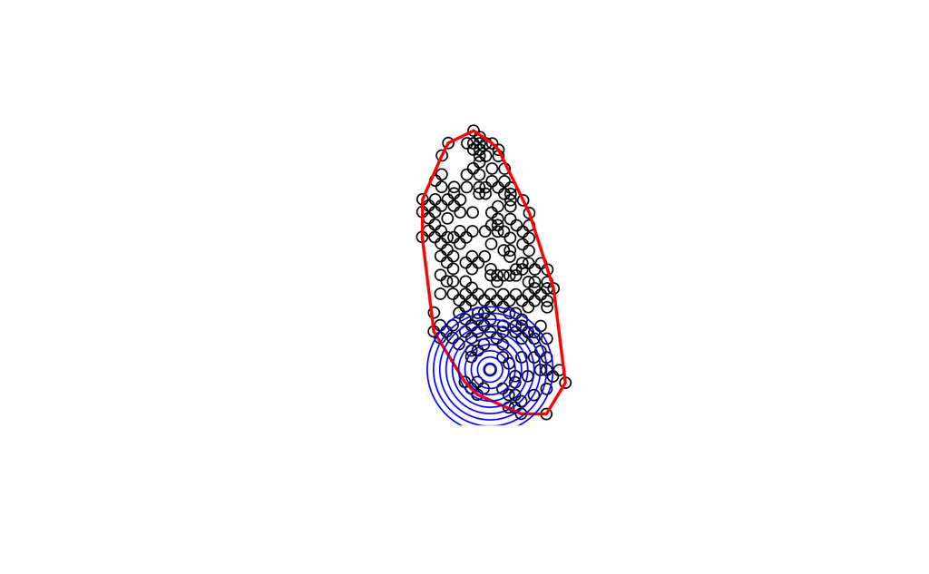

```r
for (i in seq_along(pt_in_circles))
  {
  print(pt_in_circles[[i]]$points)
  plot(st_geometry(pt_in_circles[[i]]$circle),  border = "blue", add=TRUE)
}
```

##summarize_samples A function that takes a list of groups of sites as a sample feature collections which has a dataframe with the species occurences, the polygons corresponding to the geometric delimitation of the groups of sites, a raster of habitat types, a vector of habitat names, the list of species in each group (each group is a list of numerical values of the columns corresponding to the species in the dataframe from the sample fature), and a vector with the species group names. The first column in the sample feature collection should be the name of the individual sample site. It produces a table with the area of each habitat and the number of species in each group and the total number of species.

```r
#habitat names shoudl be a df with a col with habitat codes and respective habitat names
summarize_samples<- function(samples, polygons, habitat_raster, habitat_names,
                             habitat_values, species_groups, species_group_names)
  {
    # Initialize an empty data frame for the results
    results_df <- data.frame(matrix(ncol = length(habitat_names)+
                                      length(species_group_names)+2,
                                    nrow = 0))
    colnames(results_df) <- c(habitat_names,"Area_Total",species_group_names,"Sp_Total")

    # Iterate over each area sample (i.e. group of sites)
    for (i in seq_along(samples)) {
      sample <- samples[[i]]
      polygon <- polygons[[i]]

      # Crop and mask the raster to the polygon extent
      habitat_cropped <- crop(habitat_raster, vect(polygon))
      habitat_masked <- mask(habitat_cropped, vect(polygon))

      # Calculate the area of each habitat type
      habitat_df <- freq(habitat_masked, bylayer=FALSE)
      habitat_df <- rbind(habitat_df,freq(habitat_masked, bylayer=FALSE,value=NA))

      # Ensure all possible values are included
      all_values_df <- data.frame(value = habitat_values, count = 0)

      # Merge with actual frequency data, replacing 0 where missing
      habitat_df <- merge(all_values_df, habitat_df, by = "value", all.x = TRUE)

       # Fill NA counts with 0
      habitat_df$count <- ifelse(is.na(habitat_df$count.y), 0, habitat_df$count.y)

      # Drop unnecessary column
      habitat_df <- habitat_df[, c("value", "count")]

      habitat_df$area <- habitat_df$count * res(habitat_raster)[1] * res(habitat_raster)[2]

      # Store the results
      results_df[i, seq_along(habitat_names)] <- habitat_df$area # store area of each habitat
      results_df[i, length(habitat_names)+1] <-
        sum(results_df[i, seq_along(habitat_names)]) # store total area

      # Subset species occurrences for each group
      total_species=0
      for (k in seq_along(species_groups))
      {
        group_species <- st_drop_geometry(sample)[, species_groups[[k]]+1 ]
        species_present <- colSums(group_species > 0)  # Count species occurrences
        num_species <- sum(species_present > 0)       # Number of species in the group
        results_df[i, length(habitat_names)+1+k] <- num_species #store species number in results
        total_species <- total_species + num_species
      }

      #store the total number of species by summing across species groups
      results_df[i, length(habitat_names)+length(species_groups)+2] = total_species
    }

    return(results_df)
  }
```

Try the function

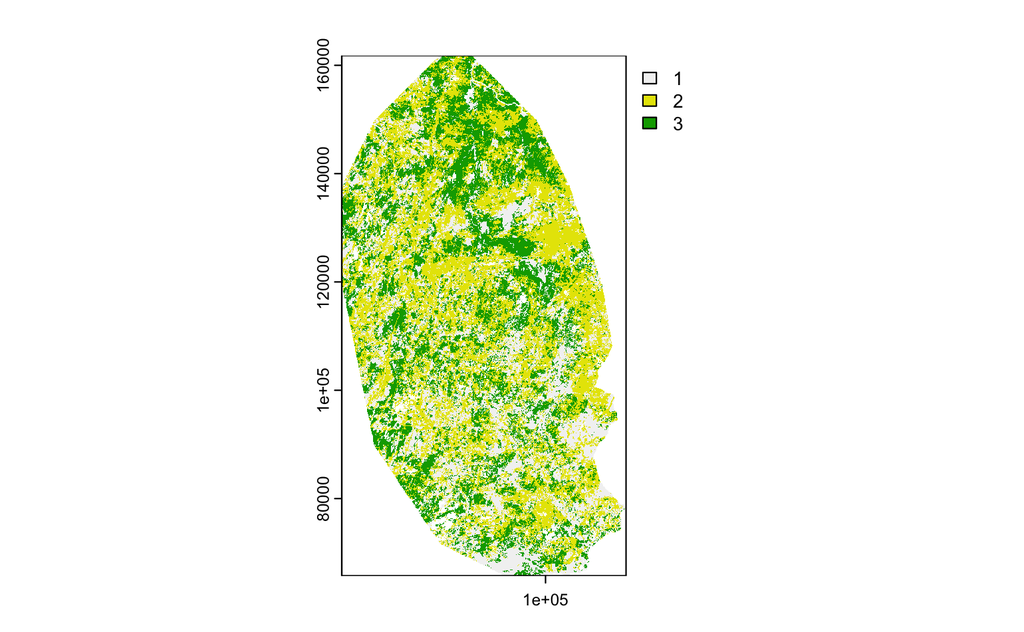

```r
lu1995 <- rast("coa95_raster_20.tif")
plot(lu1995)
```

```r
habitat_names <- c("Forest", "Agriculture", "Shrubland")
habitat_values <- c(1,2,3)
species_group_names = c("Sp_Agri", "Sp_Other")
species_groups = list(c(2,3,4),c(5,6,7))
samples=lapply(pt_in_circles, \(x) x$points)
polygons=lapply(pt_in_circles, \(x) x$circle)
res=summarize_samples(samples, polygons,
                lu1995, habitat_names, habitat_values,
                species_groups, species_group_names)
res
```

|  | Forest | Agriculture | Shrubland | Area_Total | Sp_Agri | Sp_Other | Sp_Total |
| --- | --- | --- | --- | --- | --- | --- | --- |
| 1 | 6258400 | 2810000 | 3501600 | 12570000 | 0 | 0 | 0 |
| 2 | 19606400 | 13969200 | 15144800 | 48720400 | 0 | 0 | 0 |
| 3 | 42129200 | 33955200 | 32322400 | 108406800 | 0 | 0 | 0 |
| 4 | 73915200 | 62658000 | 55706800 | 192280000 | 1 | 0 | 1 |
| 5 | 114436800 | 98037600 | 85171600 | 297646000 | 1 | 1 | 2 |
| 6 | 164414000 | 148083200 | 116504800 | 429002000 | 1 | 2 | 3 |
| 7 | 214232000 | 188793200 | 153669600 | 556694800 | 2 | 2 | 4 |
| 8 | 270077200 | 227927200 | 188311600 | 686316000 | 2 | 2 | 4 |
| 9 | 331427200 | 269444000 | 220395600 | 821266800 | 2 | 3 | 5 |
| 10 | 390368400 | 315169600 | 254599200 | 960137200 | 2 | 3 | 5 |

Now with the real species classification

```r
classif<-read_excel("coa_aves_classification.xlsx")
classif$Forest==1
```

```
  [1] FALSE  TRUE FALSE FALSE  TRUE  TRUE FALSE  TRUE FALSE FALSE  TRUE FALSE FALSE FALSE  TRUE FALSE FALSE
 [18]  TRUE FALSE FALSE FALSE  TRUE  TRUE FALSE FALSE FALSE FALSE  TRUE FALSE FALSE FALSE FALSE FALSE FALSE
 [35]  TRUE FALSE  TRUE FALSE  TRUE FALSE  TRUE  TRUE  TRUE  TRUE FALSE FALSE FALSE FALSE FALSE  TRUE FALSE
 [52]  TRUE FALSE FALSE  TRUE FALSE FALSE FALSE  TRUE FALSE  TRUE  TRUE FALSE FALSE FALSE FALSE FALSE FALSE
 [69] FALSE FALSE  TRUE  TRUE FALSE  TRUE FALSE  TRUE FALSE FALSE FALSE FALSE FALSE FALSE FALSE FALSE FALSE
 [86]  TRUE FALSE  TRUE  TRUE  TRUE  TRUE FALSE  TRUE FALSE FALSE  TRUE FALSE  TRUE  TRUE FALSE FALSE FALSE
[103]  TRUE FALSE  TRUE  TRUE FALSE FALSE FALSE  TRUE FALSE  TRUE FALSE FALSE FALSE  TRUE FALSE FALSE FALSE
[120] FALSE  TRUE FALSE  TRUE FALSE FALSE  TRUE FALSE  TRUE FALSE FALSE  TRUE  TRUE FALSE FALSE  TRUE  TRUE
[137] FALSE  TRUE FALSE
```

```r
forest=classif[classif$Forest==1,]$species
posfor=match(forest,colnames(data))-3
res=summarize_samples(samples, polygons,
                lu1995, habitat_names, habitat_values,
                list(na.omit(posfor)), list("Sp_Forest"))
res
```

|  | Forest | Agriculture | Shrubland | Area_Total | Sp_Forest | Sp_Total |
| --- | --- | --- | --- | --- | --- | --- |
| 1 | 6258400 | 2810000 | 3501600 | 12570000 | 12 | 12 |
| 2 | 19606400 | 13969200 | 15144800 | 48720400 | 12 | 12 |
| 3 | 42129200 | 33955200 | 32322400 | 108406800 | 19 | 19 |
| 4 | 73915200 | 62658000 | 55706800 | 192280000 | 24 | 24 |
| 5 | 114436800 | 98037600 | 85171600 | 297646000 | 29 | 29 |
| 6 | 164414000 | 148083200 | 116504800 | 429002000 | 29 | 29 |
| 7 | 214232000 | 188793200 | 153669600 | 556694800 | 33 | 33 |
| 8 | 270077200 | 227927200 | 188311600 | 686316000 | 34 | 34 |
| 9 | 331427200 | 269444000 | 220395600 | 821266800 | 36 | 36 |
| 10 | 390368400 | 315169600 | 254599200 | 960137200 | 37 | 37 |

##create_squares Create an sf where each sampling point is associated with a sampling square centred in the point and with a width dx.

```r
create_squares <- function(points_sf, width) {
  # Ensure the input is a point sf object
  if (!inherits(points_sf, "sf") || !inherits(st_geometry(points_sf), "sfc_POINT")) {
    stop("Input must be an sf object with point geometries.")
  }
  # Calculate half-width (to shift the square corners)
  half_width <- width / 2

  squares_sf <- st_as_sf(st_buffer(points_sf, dist = half_width, endCapStyle = "SQUARE"))

  return(squares_sf)
}
```

Try function

```r
class(points)
```

```
[1] "sf"         "tbl_df"     "tbl"        "data.frame"
```

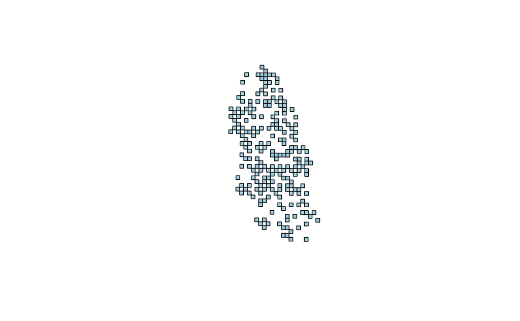

```r
squares_sf <- create_squares(points, width = 2000)

# Plot points and squares
plot(st_geometry(squares_sf), col = "lightblue", border = "black")  # Squares
```

##filter_points_in_clusters Filter points for type II/III SAR (fractals sampling scheme or sub-divisions), Points should have an associated sampling square as geometry feature instead of a point geometry.

```r
filter_points_in_clusters <- function(points_sf, squares_sf, cluster_size_vector)
  {
    npoints = nrow(points_sf)
    n_clusters_vector = npoints%/%cluster_size_vector
    n_clusters_vector[n_clusters_vector==0]=1  # when whole landscape, npoints<cluster_size
    points_within_clusters<- list()
    for (n_clusters in n_clusters_vector)
    {
      if(n_clusters==npoints)
      {
        points_in_clusters <- split(points_sf, 1:npoints)
        clusters_convex_hulls <- split(st_geometry(squares_sf), 1:npoints)
      }
      else
      {
      # Extract coordinates for k-means
      coords <- st_coordinates(points_sf)

      # Perform k-means clustering
      kmeans_result <- kmeans(coords, centers = n_clusters)

      # split the points sf into a list of clusters of points
      points_in_clusters <- split(points_sf,kmeans_result$cluster)
      squares_in_clusters <- split(squares_sf,kmeans_result$cluster)

      # Merge all squares into a single geometry
      merged_geom_within_clusters <- lapply(squares_in_clusters, st_union)

      # Compute convex hull
      clusters_convex_hulls <- lapply(merged_geom_within_clusters, st_convex_hull)

      #clusters_convex_hulls <- lapply(points_in_clusters,
      #                                   function(points) {st_convex_hull(st_union(points))})
      }
      # Add the points to the list
      points_within_clusters[[paste0("size_",
                                     cluster_size_vector[n_clusters_vector==n_clusters]) ]] <-
        list(points=points_in_clusters,chulls=clusters_convex_hulls)
    }
  # Return the list of points within clusters
  return(points_within_clusters)
}
```

Try function

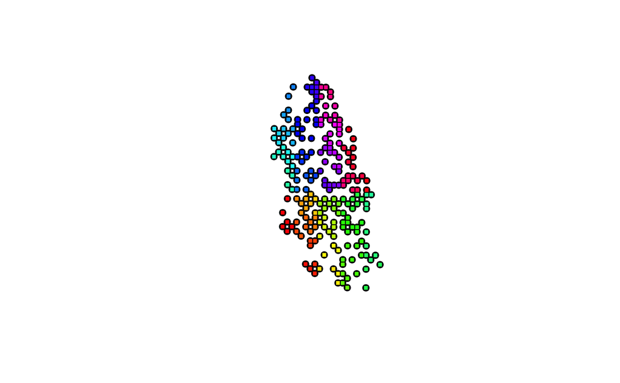

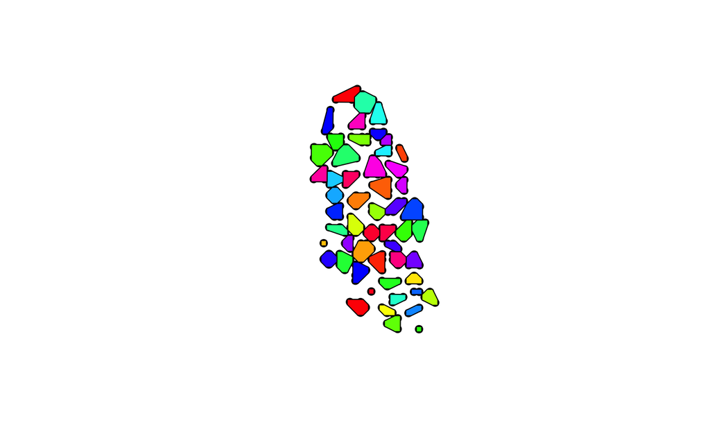

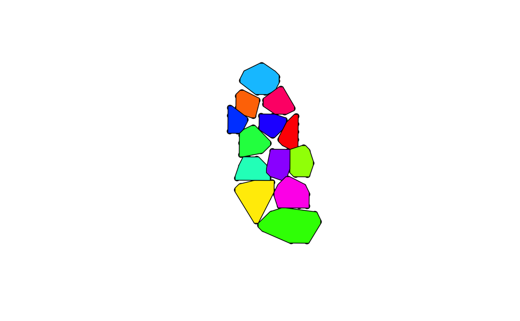

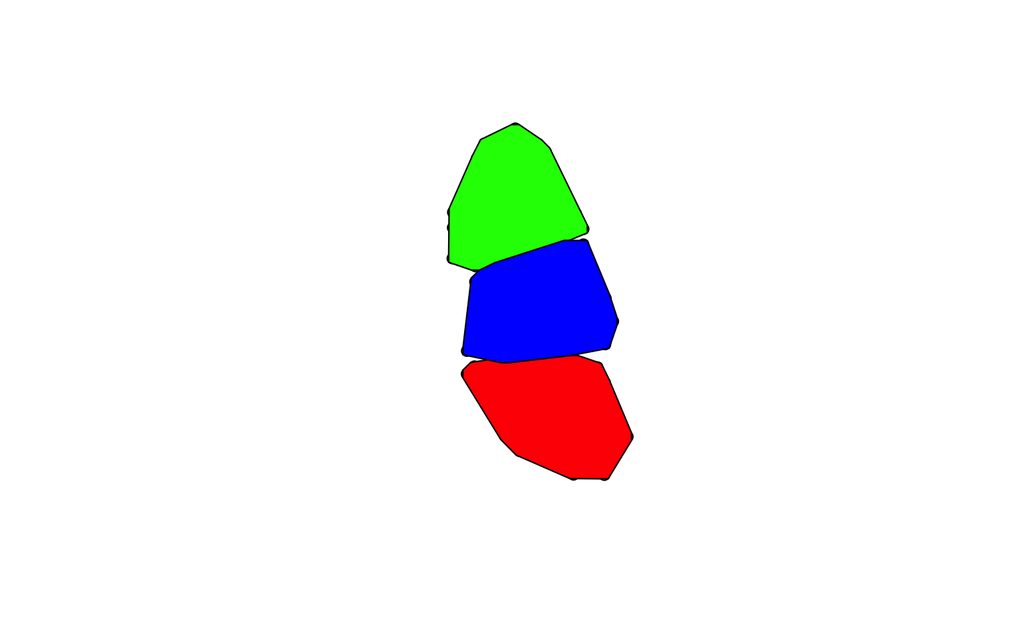

```r
squares_sf <- create_squares(points, width = 2000)
pt_in_clusters = filter_points_in_clusters(points,squares_sf,c(1,4,16,64,256))

clusters_chulls = lapply(pt_in_clusters , \(x) x$chulls)

for (size in seq_along(clusters_chulls))
{
  # Set up colors
colors <- rainbow(length(clusters_chulls[[size]]))
plot(st_geometry(points))
# Add remaining polygons with different colors
  for (i in 1:length(clusters_chulls[[size]])) {
    plot(clusters_chulls[[size]][[i]], col = colors[i], border = "black", add = TRUE)
  }
}
```

[figure not shown]

```r
NA
```

##sumarize the samples for SAR type III

```r
extract_species_positions <- function(species_habitat_matrix, species_site_matrix) {
  # Get habitat names
  habitat_names <- colnames(species_habitat_matrix[,-1])

  # Initialize a list to store species positions for each habitat
  habitat_positions <- list()

  # Loop through each habitat
  for (habitat in habitat_names) {
    # Get species associated with this habitat
    species_in_habitat <-
      rownames(species_habitat_matrix)[species_habitat_matrix[, habitat] == 1]

    # Find positions (indices) of these species in the species-site matrix
    species_positions <- which(rownames(species_site_matrix) %in% species_in_habitat)

    # Store results in the list
    habitat_positions[[habitat]] <- species_positions
  }

  return(habitat_positions)
}
```

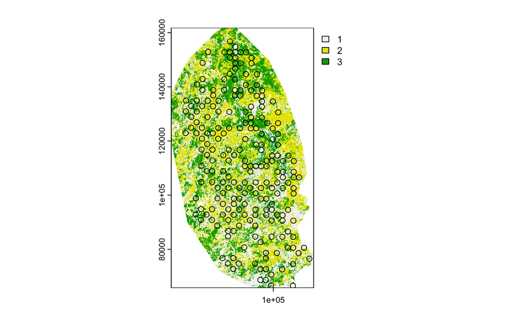

```r
lu1995 <- rast("coa95_raster_20.tif")
plot(lu1995)
plot(st_geometry(points),add=TRUE)
```

```r
squares_sf <- create_squares(points, width = 2000)
pt_in_clusters = filter_points_in_clusters(points,squares_sf,c(1,4,16,64,256))
habitat_names <- c("Forest", "Agriculture", "Shrubland","Other")
habitat_values <- c(1,2,3,NA)
species_group_names = c("Sp_Forest", "Sp_Other")

classif<-read_excel("coa_aves_classification_v2.xlsx")
species_groups = extract_species_positions(classif,points[,-1])

samples=lapply(pt_in_clusters , \(x) x$points)
polygons=lapply(pt_in_clusters , \(x) x$chulls)
res=summarize_samples(flatten(samples), flatten(polygons),
                lu1995, habitat_names, habitat_values, species_groups,
                names(species_groups))
res
```

|  | Forest | Agriculture | Shrubland | Other | Area_Total | Forest_Sp | Shrub_Sp | Grassland_Sp | generalists_Sp | other_specialists_Sp | Sp_Total |
| --- | --- | --- | --- | --- | --- | --- | --- | --- | --- | --- | --- |
| 1 | 810000 | 716000 | 2014800 | 459200 | 4000000 | 12 | 0 | 2 | 6 | 1 | 21 |
| 2 | 1392000 | 540800 | 1986800 | 80400 | 4000000 | 11 | 1 | 4 | 3 | 1 | 20 |
| 3 | 1819200 | 1674400 | 237600 | 268800 | 4000000 | 9 | 0 | 4 | 1 | 2 | 16 |
| 4 | 1474800 | 942400 | 1424000 | 158800 | 4000000 | 11 | 0 | 4 | 3 | 0 | 18 |
| 5 | 1302800 | 754400 | 1906000 | 36800 | 4000000 | 8 | 0 | 2 | 2 | 3 | 15 |
| 6 | 531200 | 934400 | 2484800 | 49600 | 4000000 | 11 | 0 | 2 | 4 | 4 | 21 |
| 7 | 522800 | 220000 | 1274800 | 1982400 | 4000000 | 9 | 0 | 2 | 3 | 2 | 16 |
| 8 | 1196800 | 900000 | 976800 | 926400 | 4000000 | 11 | 0 | 5 | 4 | 2 | 22 |
| 9 | 2034400 | 820800 | 1102800 | 42000 | 4000000 | 14 | 0 | 4 | 3 | 1 | 22 |
| 10 | 1837200 | 1131200 | 1023200 | 8400 | 4000000 | 11 | 0 | 1 | 8 | 4 | 24 |

[output cut: 273 more lines]

# SAR analysis

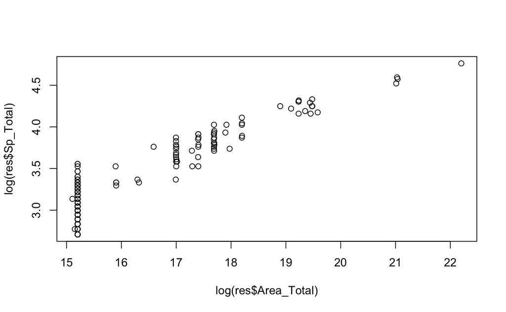

```r
#devtools::install_github("txm676/sars")
library(sars)
help("sar_countryside")
plot(log(res$Area_Total),log(res$Sp_Total))
```

```r
sar=lm(log(res$Sp_Total)~log(res$Area_Total))
summary(sar)
```

```
Call:
lm(formula = log(res$Sp_Total) ~ log(res$Area_Total))

Residuals:
     Min       1Q   Median       3Q      Max
-0.36616 -0.14777  0.00638  0.13991  0.51720

Coefficients:
                     Estimate Std. Error t value Pr(>|t|)
(Intercept)         -1.502443   0.132834  -11.31   <2e-16 ***
log(res$Area_Total)  0.298687   0.008344   35.80   <2e-16 ***
---
Signif. codes:  0 ‘***’ 0.001 ‘**’ 0.01 ‘*’ 0.05 ‘.’ 0.1 ‘ ’ 1

Residual standard error: 0.1861 on 281 degrees of freedom
Multiple R-squared:  0.8201,    Adjusted R-squared:  0.8195
F-statistic:  1281 on 1 and 281 DF,  p-value: < 2.2e-16
```

```r
datacsar=res[,-c(4,5,7,10,11)]
species_group_names=colnames(datacsar[,c(-1,-2,-3)])

s3 <- sar_countryside(data = datacsar, modType = "power",
                      gridStart = "partial",
                      habNam = habitat_names[-4],
                      spNam = species_group_names)
s3
```

```
sar_countryside model fits (power form)

All models could be fitted.

Model fits:

Forest_Sp :
Nonlinear regression model
  model: S ~ (h1 * Area1 + h2 * Area2 + h3 * Area3)^z
   data: dat
      h1       h2       h3        z
0.010380 0.006651 0.001519 0.236145
 residual sum-of-squares: 2315

Number of iterations to convergence: 19
Achieved convergence tolerance: 1.49e-08

Grassland_Sp :
Nonlinear regression model
  model: S ~ (h1 * Area1 + h2 * Area2 + h3 * Area3)^z
   data: dat
       h1        h2        h3         z
0.000e+00 6.712e-05 1.609e-05 2.611e-01
 residual sum-of-squares: 696.5

Number of iterations to convergence: 33
Achieved convergence tolerance: 1.49e-08

generalists_Sp :
Nonlinear regression model
  model: S ~ (h1 * Area1 + h2 * Area2 + h3 * Area3)^z
   data: dat
       h1        h2        h3         z
3.090e-05 4.888e-05 4.212e-05 3.229e-01
 residual sum-of-squares: 1266

Number of iterations to convergence: 11
Achieved convergence tolerance: 1.49e-08


```

[output cut: 20 more lines]

```
      0.34004283       0.08138300       0.04054685


Predicted total richness values:

       1        2        3        4        5
17.99943 18.58365 19.92579 19.05678 18.81315

...Remaining values cut-off ...


Residual sum of squares [based on total richness]:

Countryside_RSS       Power_RSS
       6207.181        6279.261
```